# TRANSFORMER

## Table of contents

- 1 .Intro
- 2. Setup
- 3. Positional Encoding
  - 3.1. Concept and motivation
  - 3.2. Implementation
- 4. Masking
  - 4.1. Padding Mask
  - 4.2. Look Ahead Mask
- 5. Attention
  - 5.1. Types of Attention
  - 5.2. Scaled dot-product attention
  - 5.3. Multi-head Attention
  - 5.3. Multi-head Attention
- 6. Feed Forward Neural Network
- 7. Encoder
  - 7.1. Encoder Layer
  - 7.2. Full Encoder
- 8. Decoder
  - 8.1. Decoder Layer
  - 8.2. Full Decoder
- 9. Transformer
  - 9.1. Model
  - 9.2. Training and preidctions
- ANNEX
  - Custom Training
- References

## **1. Intro**

This notebook is dedicated to implementing a Transformer model from scratch, following the architecture described in the groundbreaking paper "Attention Is All You Need" by Vaswani et al. The primary objective of this implementation is to learn and understand the inner workings of Transformers, rather than simply using prebuilt libraries.

I am going to cover key components such as:

- Positional Encoding: Injecting order into sequences.
- Scaled Dot-Product Attention: The core mechanism behind attention.
- Multi-Head Attention: Learning diverse relationships in data.
- Feed-Forward Networks: Extending attention's capabilities.
- Layer Normalization and Residual Connections: Stabilizing and enhancing learning.
- Encoder-Decoder Structure: Processing input and generating output.

By the end of this notebook, you should gain a conceptual understanding of each component and how they fit together to form the Transformer. This hands-on approach will help demystify the architecture and prepare you to adapt or experiment with it for your own projects.

## **2. Setup**

```python
import tensorflow as tf
import pandas as pd
import time
import numpy as np
import matplotlib.pyplot as plt

from tensorflow.keras.layers import Embedding, MultiHeadAttention, Dense, Input, Dropout, LayerNormalization
from transformers import DistilBertTokenizerFast #, TFDistilBertModel
from transformers import TFDistilBertForTokenClassification
from tqdm import tqdm_notebook as tqdm
```

```python
# Set the print options
np.set_printoptions(precision=3)
```

## **3. Positional Encoding**

### **3.1. Concept and motivation**

In sequence to sequence tasks, the relative order of your data is extremely important to its meaning. When you were training sequential neural networks such as RNNs, you fed your inputs into the network in order. Information about the order of your data was automatically fed into your model. However, when you train a Transformer network, you feed your data into the model all at once. While this dramatically reduces training time, there is no information about the order of your data. This is where positional encoding is useful - you can specifically encode the positions of your inputs and pass them into the network.

There are various types of positional encoding, for example:

- Sinusoidal encoding
- Learned Positional Encoding
- Relative Positional encoding

In this notebook I will use the sinusoidal encoding, given by the following formulas:

$$ PE_{(pos, 2i)}= sin\left(\frac{pos}{{n}^{\frac{2i}{d}}}\right) \tag{1}$$
$$ PE_{(pos, 2i+1)}= cos\left(\frac{pos}{{n}^{\frac{2i}{d}}}\right) \tag{2}$$

where:

- $d$ is the dimension of the word embedding and positional encoding
- $pos$ is the position of the word.
- $i$ refers to each of the different dimensions of the positional encoding.
- $n$ is a user defined scalar (10000 in the paper)

The values of the sine and cosine equations are small enough (between -1 and 1) that when you add the positional encoding to a word embedding, the word embedding is not significantly distorted. The sum of the positional encoding and word embeding is ultimately what is fed into the model. Using a combination of these two equations helps your Transformer network attend to the relative positions of your input data.

In this notebook I am going to use horizontal vectors, that's why all the matrix multiplications should be adjusted accordingly.

Let’s clarify the **number of positions in the sequence** with an example.

Imagine you have a sequence of words: ["The", "cat", "sat", "on", "the", "mat"].

Here:

- Each word in the sequence corresponds to a position.
- The total number of positions is the number of words in the sequence, which is 6 in this case.

Now, if you're embedding these words (e.g., using word embeddings), you might represent the sequence as a matrix where:

- Rows correspond to positions in the sequence (one row for each word).
- Columns correspond to the embedding dimensions (let’s assume d=4 for simplicity).

### **3.2. Implementation**

```python
# helper function: get the angles for the positional encoding
def get_angles(pos, i, d, n=10000):
    """
    Get the angles for the positional encoding

    Arguments:
        pos -- Column vector containing the positions [[0], [1], ...,[N-1]]
        i --   Row vector containing the dimension span [[0, 1, 2, ..., d-1]]
        d(integer) -- Encoding size
        n -- user defined scalar

    Returns:
        angles -- (pos, d) numpy array
    """
    angles = pos/ (np.power(n, (2 * (i//2)) / np.float32(d)))


    return angles
```

```python
# NOTE
for i in range(4):
    print(f"If i = {i} -> i//2 = {i//2}")
```

```
If i = 0 -> i//2 = 0
If i = 1 -> i//2 = 0
If i = 2 -> i//2 = 1
If i = 3 -> i//2 = 1
```

Let's try our function.

First let's remember that we can use np.newaxis to add an extra dimension to a numpy array.

For example, in np.arange(7)[:, np.newaxis], [:, np.newaxis] adds a new axis (dimension) to the array along the columns, essentially converting the 1D array into a 2D column vector.

In the case of np.arange(3)[np.newaxis, :], the new axis is added along the rows, resulting in a row vector.

```python
np.arange(7).shape, np.arange(7)[:, np.newaxis].shape, np.arange(3).shape,  np.arange(3)[np.newaxis, :].shape
```

```
((7,), (7, 1), (3,), (1, 3))
```

```python
np.arange(7), np.arange(7)[:, np.newaxis]
```

```
(array([0, 1, 2, 3, 4, 5, 6]),
 array([[0],
        [1],
        [2],
        [3],
        [4],
        [5],
        [6]]))
```

```python
np.arange(3), np.arange(3)[np.newaxis, :]
```

```
(array([0, 1, 2]), array([[0, 1, 2]]))
```

```python
example = get_angles(np.arange(7)[:, np.newaxis], np.arange(3)[np.newaxis, :], 4)
print(example.shape)
example
```

```
(7, 3)
```

```
array([[0.  , 0.  , 0.  ],
       [1.  , 1.  , 0.01],
       [2.  , 2.  , 0.02],
       [3.  , 3.  , 0.03],
       [4.  , 4.  , 0.04],
       [5.  , 5.  , 0.05],
       [6.  , 6.  , 0.06]])
```

Now, let's implement the positional encoding. We have to use the sine equation when $i$ is an even number and the cosine equation when $i$ is an odd number.

```python
def positional_encoding(positions, d):
    """
    Precomputes a matrix with all the positional encodings

    Arguments:
        positions (int) -- Maximum number of positions to be encoded
        d (int) -- Encoding size

    Returns:
        pos_encoding -- (1, position, d_model) A matrix with the positional encodings
    """
    # initialize a matrix angle_rads of all the angles
    angle_rads = get_angles(np.arange(positions)[:, np.newaxis],
                            np.arange(d)[ np.newaxis,:],
                            d)

    # -> angle_rads has dim (positions,d)

    # apply sin to even indices in the array; 2i
    angle_rads[:, 0::2] = np.sin(angle_rads[:, 0::2])

    # apply cos to odd indices in the array; 2i+1
    angle_rads[:, 1::2] = np.cos(angle_rads[:, 1::2])

    # #  add an extra dimension at the beginning of the array,
    # so the final shape of pos_encoding becomes (1, positions, d)
    pos_encoding = angle_rads[np.newaxis, ...]

    return tf.cast(pos_encoding, dtype=tf.float32)
```

**Note.**. Let's talk a little bit more about the line "pos_encoding = angle_rads[np.newaxis, ...]". The purpose of np.newaxis is to add an extra dimension at the beginning of the array, so the final shape of pos_encoding becomes (1, positions, d). This means the positional encoding has an additional dimension at the start, representing a "batch" of size 1 (this is typical in TensorFlow and other deep learning frameworks).

For example, if positions = 3 and d = 4, the shape of pos_encoding will be (1, 3, 4).

- 1 represents the batch size (in this case, just one sequence set).
- 3 is the number of positions in the sequence.
- 4 is the size of the embedding vectors.

To retrieve the positional encoding for the positions, you can take pos_encoding[0], which selects the matrix with dimensions (3, 4). This is the positional encoding to be added to your input embeddings, representing the application of positional encoding to your input sequence.

Let's try our function.

```python
# 8 positions with an embedding size of 3
example = positional_encoding(8, 3)
example
```

```
<tf.Tensor: shape=(1, 8, 3), dtype=float32, numpy=
array([[[ 0.   ,  1.   ,  0.   ],
        [ 0.841,  0.54 ,  0.002],
        [ 0.909, -0.416,  0.004],
        [ 0.141, -0.99 ,  0.006],
        [-0.757, -0.654,  0.009],
        [-0.959,  0.284,  0.011],
        [-0.279,  0.96 ,  0.013],
        [ 0.657,  0.754,  0.015]]], dtype=float32)>
```

```python
example[0]
```

```
<tf.Tensor: shape=(8, 3), dtype=float32, numpy=
array([[ 0.   ,  1.   ,  0.   ],
       [ 0.841,  0.54 ,  0.002],
       [ 0.909, -0.416,  0.004],
       [ 0.141, -0.99 ,  0.006],
       [-0.757, -0.654,  0.009],
       [-0.959,  0.284,  0.011],
       [-0.279,  0.96 ,  0.013],
       [ 0.657,  0.754,  0.015]], dtype=float32)>
```

Let's plot our positional encodings.

```
(1, 50, 512)
```

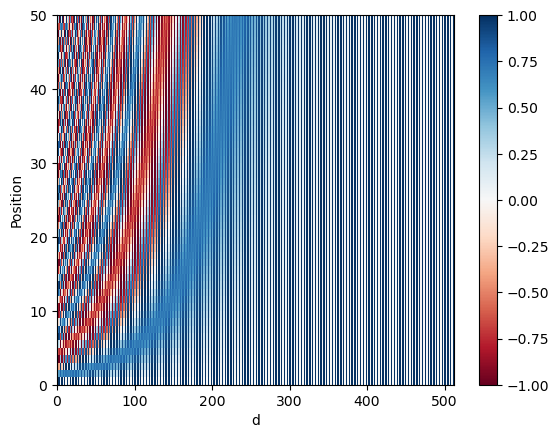

```python
num_positions = 50
d = 512

pos_encoding = positional_encoding(num_positions, d)

print (pos_encoding.shape)

plt.pcolormesh(pos_encoding[0], cmap='RdBu') # we take pos_encoding[0] (we remove batch dimension)
plt.xlabel('d')
plt.xlim((0, d))
plt.ylabel('Position')
plt.colorbar()
plt.show()
```

Each row represents a positional encoding - notice how none of the rows are identical! We have created a unique positional encoding for each of the words.

Finally, let's look at an example where we add the positional encoding to the word embeddings.

[figure not shown]

```python
# Let' say that we have an embedding with 3 tokens and 4 dimensions


# input text: "I am happy"
embedding = np.array([[0.1, 0.2, 0.3, 0.4], # corresponds to "I"
                     [0.5, 0.6, 0.7, 0.8],  # corresponds to "am"
                     [0.9, 1.0, 1.1, 1.2]]) # corresponds to "happy"

embedding = tf.constant(embedding, dtype=tf.float32)

# Positional encoding for a sequence of length 3 and embedding size 4
pos_encoding = positional_encoding(3, 4)

# sum of embedding with positional encoding
encoded_input = embedding + pos_encoding[0]

# Results
print("\033[1mInput embedding:\033[0m")
print(embedding)

print("\033[1m\nPositional Encoding:\033[0m")
print(pos_encoding)

print("\033[1m\nSum of the embedding with positional encoding:\033[0m")
print(encoded_input)
```

```
Input embedding:
tf.Tensor(
[[0.1 0.2 0.3 0.4]
 [0.5 0.6 0.7 0.8]
 [0.9 1.  1.1 1.2]], shape=(3, 4), dtype=float32)

Positional Encoding:
tf.Tensor(
[[[ 0.     1.     0.     1.   ]
  [ 0.841  0.54   0.01   1.   ]
  [ 0.909 -0.416  0.02   1.   ]]], shape=(1, 3, 4), dtype=float32)

Sum of the embedding with positional encoding:
tf.Tensor(
[[0.1   1.2   0.3   1.4  ]
 [1.341 1.14  0.71  1.8  ]
 [1.809 0.584 1.12  2.2  ]], shape=(3, 4), dtype=float32)
```

## **4. Masking**

There are two types of masks that are useful when building your Transformer network:

- The *padding mask*
- The *look-ahead mask*

Both help the softmax computation give the appropriate weights to the words in your input sentence.

### **4.1. Padding mask**

Oftentimes your input sequence will exceed the maximum length of a sequence your network can process. Let's say the maximum length of your model is five, it is fed the following sequences:

```
[["Do", "you", "know", "when", "Jane", "is", "going", "to", "visit", "Africa"],
 ["Jane", "visits", "Africa", "in", "September" ],
 ["Exciting", "!"]
]
```

which might get vectorized as:

```
[[ 71, 121, 4, 56, 99, 2344, 345, 1284, 15],
 [ 56, 1285, 15, 181, 545],
 [ 87, 600]
]
```

When passing sequences into a transformer model, it is important that they are of uniform length. You can achieve this by padding the sequence with zeros, and truncating sentences that exceed the maximum length of your model:

```
[[ 71, 121, 4, 56, 99],
 [ 2344, 345, 1284, 15, 0],
 [ 56, 1285, 15, 181, 545],
 [ 87, 600, 0, 0, 0],
]
```

Sequences longer than the maximum length of five will be truncated, and zeros will be added to the truncated sequence to achieve uniform length. Similarly, for sequences shorter than the maximum length, they zeros will also be added for padding. However, these zeros will affect the softmax calculation - this is when a padding mask comes in handy! By multiplying a padding mask by a small negative number (for example -1e9) and adding it to your sequence, you mask out the zeros by setting them to close to negative infinity.

After masking, your input should go from `[87, 600, 0, 0, 0]` to `[87, 600, -1e9, -1e9, -1e9]`, so that when you take the softmax, the zeros don't affect the score.

Let's remember that in in a softmax function, when x approach to -infinity, the value tends to 0.

[figure not shown]

We will use [tf.math.equal](https://www.tensorflow.org/api_docs/python/tf/math/equal)

```python
# Example sequence
seq = tf.constant([[1, 0, 3], [4, 0, 6]])
print(f"Original data:\n {seq}")

# Check where elements are equal to 0
mask = tf.math.equal(seq, 0)  # Result: [[False, True, False], [False, True, False]]
print(f"\n Mask:\n {mask}")

# Convert to float32
mask_float = tf.cast(mask, tf.float32)  # Result: [[0.0, 1.0, 0.0], [0.0, 1.0, 0.0]]

print(f"\n Mask Float:\n {mask_float}")
```

```
Original data:
 [[1 0 3]
 [4 0 6]]

 Mask:
 [[False  True False]
 [False  True False]]

 Mask Float:
 [[0. 1. 0.]
 [0. 1. 0.]]
```

```python
def create_padding_mask(seq):
    """
    Creates a matrix mask for the padding cells

    Arguments:
        seq -- (n, m) matrix

    Returns:
        mask -- (n, 1, 1, m) binary tensor
    """
    seq = tf.cast(tf.math.equal(seq, 0), tf.float32)

    # add extra dimensions to add the padding
    # to the attention logits.
    return seq[:, tf.newaxis, tf.newaxis, :] # shape (n, 1, 1, m)
```

```python
# Let's try our function

x = tf.constant([[7., 6., 0., 0., 1.], [1., 2., 3., 0., 0.], [0., 0., 0., 4., 5.]])
print(create_padding_mask(x))
```

```
tf.Tensor(
[[[[0. 0. 1. 1. 0.]]]


 [[[0. 0. 0. 1. 1.]]]


 [[[1. 1. 1. 0. 0.]]]], shape=(3, 1, 1, 5), dtype=float32)
```

```python
create_padding_mask(x) * -1.0e9
```

```
<tf.Tensor: shape=(3, 1, 1, 5), dtype=float32, numpy=
array([[[[-0.e+00, -0.e+00, -1.e+09, -1.e+09, -0.e+00]]],


       [[[-0.e+00, -0.e+00, -0.e+00, -1.e+09, -1.e+09]]],


       [[[-1.e+09, -1.e+09, -1.e+09, -0.e+00, -0.e+00]]]], dtype=float32)>
```

We will now see that the difference between the softmax of x and that of x added to this mask is very small.

```python
tf.keras.activations.softmax(x)
```

```
<tf.Tensor: shape=(3, 5), dtype=float32, numpy=
array([[7.288e-01, 2.681e-01, 6.645e-04, 6.645e-04, 1.806e-03],
       [8.444e-02, 2.295e-01, 6.239e-01, 3.106e-02, 3.106e-02],
       [4.854e-03, 4.854e-03, 4.854e-03, 2.650e-01, 7.204e-01]],
      dtype=float32)>
```

```python
tf.keras.activations.softmax(x + create_padding_mask(x) * -1.0e9, axis=-1)
```

```
<tf.Tensor: shape=(3, 1, 3, 5), dtype=float32, numpy=
array([[[[7.297e-01, 2.685e-01, 0.000e+00, 0.000e+00, 1.809e-03],
         [2.447e-01, 6.652e-01, 0.000e+00, 0.000e+00, 9.003e-02],
         [6.648e-03, 6.648e-03, 0.000e+00, 0.000e+00, 9.867e-01]]],


       [[[7.306e-01, 2.688e-01, 6.662e-04, 0.000e+00, 0.000e+00],
         [9.003e-02, 2.447e-01, 6.652e-01, 0.000e+00, 0.000e+00],
         [3.333e-01, 3.333e-01, 3.333e-01, 0.000e+00, 0.000e+00]]],


       [[[0.000e+00, 0.000e+00, 0.000e+00, 2.689e-01, 7.311e-01],
         [0.000e+00, 0.000e+00, 0.000e+00, 5.000e-01, 5.000e-01],
         [0.000e+00, 0.000e+00, 0.000e+00, 2.689e-01, 7.311e-01]]]],
      dtype=float32)>
```

**Summary**

- Padding Mask
  - A mask that indicates which elements in the sequence are padding and which are not.
- Usage in Attention.
  - It ensures that padding values do not affect the attention scores and, therefore, the result of the softmax.
- Effect:
  - Padding values do not influence the calculation of the output representations, allowing the model to focus only on the relevant parts of the sequence.

This is crucial for proper training and for preventing the model from being "confused" by the artificially added zeros.

### **4.2. Look-ahead mask**

The look-ahead mask (or causal mask) is a special type of mask used in the Transformer, especially in the context of the decoder. Its main function is to prevent the model from using future information when predicting the next word or token in a sequence, ensuring that the model is autoregressive.

Why is it used? The purpose of the look-ahead mask is to prevent the model from seeing the future when generating an output sequence. This means that when the model is predicting the token at position i, it should not "see" tokens at later positions (i+1, i+2, ...). This is crucial during both training and inference because, during inference, the model does not have access to future sequence information.

How does it work? The look-ahead mask is a lower triangular matrix (with 1s in the lower part and 0s in the upper part), which is applied to the attention scores. This mask ensures that the attention values corresponding to future tokens in the sequence are masked.

During the attention calculation, the attention scores for elements at future positions are set to a very negative value (e.g., negative infinity), so that after applying softmax, these positions do not influence the probability calculation.

For example, if the expected correct output is `[1, 2, 3]` and you wanted to see if given that the model correctly predicted the first value it could predict the second value, you would mask out the second and third values. So you would input the masked sequence `[1, -1e9, -1e9]` and see if it could generate `[1, 2, -1e9]`.

For the implementation we will use [tf.linalg.band_part](https://www.tensorflow.org/api_docs/python/tf/linalg/band_part).

More specifically:

tf.linalg.band_part(matrix, -1, 0):

This is a function that extracts the lower triangular part of a matrix, with the specific options given:

- matrix: The matrix to extract from, which is the matrix of ones in this case.
- -1: The number of diagonals to include below the main diagonal. A value of -1 means all diagonals below the main diagonal.
- 0: The number of diagonals to include above the main diagonal. A value of 0 means no diagonals above the main diagonal are included.

So, it creates a lower triangular matrix, meaning it keeps the elements below and on the main diagonal, and sets all the elements above the main diagonal to 0.

```python
def create_look_ahead_mask(size):
    """
    Returns an upper triangular matrix filled with ones

    Arguments:
        size -- matrix size

    Returns:
        mask -- (size, size) tensor
    """
    mask = tf.linalg.band_part(tf.ones((size, size)), -1, 0)
    return mask
```

```python
# Let's try
x = tf.random.uniform((1, 3))
temp = create_look_ahead_mask(x.shape[1])

temp
```

```
<tf.Tensor: shape=(3, 3), dtype=float32, numpy=
array([[1., 0., 0.],
       [1., 1., 0.],
       [1., 1., 1.]], dtype=float32)>
```

**Summary**

- Look-ahead mask:
  - A mask used in the decoder to prevent the model from seeing future tokens when making predictions in a sequence.
- Purpose:
  - Ensure that the model is autoregressive and generates tokens in sequential order, without accessing future information.

## **5. Attention**

### **5.1. Types of Attention**

The 3 main types of attention in the transformer model are:

- Encoder-decoder attention.
- Self-Attention
- Masked Self-Attention

### Encoder decoder-attention

The words in one sentence attend to all other words in another one.

That is, the queries come from one sentence while the keys and values come from another.

It is crucial for tasks like translation, where the decoder generates words based on the source sentence.

[figure not shown]

### Self-attention

**The queries, keys, and values come from the same sentence.**

Every word attends to every other word in the sequence.

This type of attention lets you get contextual representations of your words. In other terms, self-attention gives you a representation of the meaning of each word within the sentence.

[figure not shown]

### Masked self-attention

Queries, keys and values also come from the same sentence, but **each query cannot attend to keys on future positions.**

This attention mechanism is present in the decoder from the transformer model and ensures that predictions at each position depend only on the known outputs.

- The scale dot-product attention requires the calculation of the softmax of the scaled products between the queries and the transpose of the key matrix. Then for mask self-attention, you add a mask matrix within the softmax.
  - The mask has a zero on all of its positions, except for the elements above the diagonal, which are set to minus infinity (or, in practice, a huge negative number).
- After taking the softmax, this addition ensures that the elements in the weights matrix are 0 for all the keys and the subsequent positions to the query.
- In the end, as with the other types of attention, you multiply the weights matrix by the value matrix to get the context vector for each query.

[figure not shown]

### **5.2. Scaled dot-product attention**

In scale dot-products attention:

- We have queries, keys and values.
- The attention layer outputs context vectors for each query.
  - The context vectors are weighted sums of the values where the similarity between the queries and keys determines the weights assigned to each value.
- The softmax ensures that the weights add up to 1.
- The division by the square roots of the dimension of the key factors is used to improve performance.

Mathematically:

$$ \text { Attention }(Q, K, V)=\operatorname{softmax}\left(\frac{Q K^{T}}{\sqrt{d_{k}}}\right) V\tag{4}\ $$

- $Q$ is the matrix of queries
- $K$ is the matrix of keys
- $V$ is the matrix of values
- ${d_k}$ is the dimension of the keys, which is used to scale everything down so the softmax doesn't explode.

The scale dot-product attention mechanism is very efficient since it relies only on matrix multiplication and a softmax. Additionally, we can implement this attention mechanism to run on GPUs or TPUs to speed up training.

To get the query, key and value matrices, you must first transform the words in your sequences toward embeddings.

You will generally use the same vectors used for the key matrix for the value matrix. But you could also transform them first.

Note that the number of vectors used to form the key and value matrix must be the same.

[figure not shown]

Now, we can implement the formula.

[figure not shown]

```python
def scaled_dot_product_attention_v0(q, k, v):
    """
    Calculate the attention weights.
      q, k, v must have matching leading dimensions.
      k, v must have matching penultimate dimension, i.e.: seq_len_k = seq_len_v.
      The mask has different shapes depending on its type(padding or look ahead)
      but it must be broadcastable for addition.

    Arguments:
        q -- query shape == (..., seq_len_q, depth)
        k -- key shape == (..., seq_len_k, depth)
        v -- value shape == (..., seq_len_v, depth_v)

    Returns:
        output -- attention_weights
    """

    # Q*K'
    matmul_qk = tf.matmul(q, k, transpose_b=True)

    # scale matmul_qk
    dk = tf.cast(tf.shape(k)[-1], tf.float32)
    scaled_attention_logits = matmul_qk / tf.math.sqrt(dk)

    # softmax is normalized on the last axis (seq_len_k) so that the scores
    # add up to 1.
    attention_weights = tf.nn.softmax(scaled_attention_logits, axis=-1)  # (..., seq_len_q, seq_len_k)

    # attention_weights * V
    output = tf.matmul(attention_weights, v)   # (..., seq_len_q, depth_v)

    return output, attention_weights
```

**Note.** About the ellipsis in the docstring.

The ... (ellipsis) represents the batch dimensions and any additional dimensions (e.g., for multi-head attention or hierarchical models). In simpler cases, this is just the batch size. For example:

- In a single-head attention scenario, the shape might be (batch_size,).
- In a multi-head attention scenario, the shape might be (batch_size, num_heads).

```python
# Example: Query, Key, Value tensors
batch_size = 2  # Number of sequences in the batch
seq_len_q = 3   # Length of the query sequence
seq_len_kv = 4  # Length of the key and value sequences
depth = 5       # Embedding size for query/key
depth_v = 6     # Embedding size for value

# Generate random tensors for q, k, v
q = tf.random.uniform((batch_size, seq_len_q, depth))   # Shape: (2, 3, 5)
k = tf.random.uniform((batch_size, seq_len_kv, depth))  # Shape: (2, 4, 5)
v = tf.random.uniform((batch_size, seq_len_kv, depth_v))  # Shape: (2, 4, 6)

# Apply scaled dot-product attention
output, attention_weights = scaled_dot_product_attention_v0(q, k, v)

# Print shapes and results
print("\033[1mQuery shape:\033[0m", q.shape)
print("\033[1mKey shape:\033[0m", k.shape)
print("\033[1mValue shape:\033[0m", v.shape)
print("\033[1mOutput shape:\033[0m", output.shape)  # Should match (batch_size, seq_len_q, depth_v)
print("\033[1mAttention weights shape:\033[0m", attention_weights.shape)  # Should match (batch_size, seq_len_q, seq_len_kv)

# Print the tensors (optional)
print("\n\033[1mAttention Weights:\033[0m\n", attention_weights)
print("\n\033[1mOutput:\033[0m\n", output)
```

```
Query shape: (2, 3, 5)
Key shape: (2, 4, 5)
Value shape: (2, 4, 6)
Output shape: (2, 3, 6)
Attention weights shape: (2, 3, 4)

Attention Weights:
 tf.Tensor(
[[[0.259 0.257 0.217 0.266]
  [0.25  0.215 0.209 0.326]
  [0.274 0.267 0.188 0.272]]

 [[0.289 0.262 0.24  0.209]
  [0.28  0.29  0.24  0.19 ]
  [0.29  0.25  0.239 0.221]]], shape=(2, 3, 4), dtype=float32)

Output:
 tf.Tensor(
[[[0.556 0.206 0.584 0.392 0.253 0.557]
  [0.532 0.189 0.579 0.375 0.248 0.602]
  [0.573 0.205 0.582 0.372 0.238 0.548]]

 [[0.36  0.586 0.605 0.499 0.489 0.295]
  [0.363 0.594 0.611 0.501 0.47  0.301]
  [0.359 0.581 0.604 0.502 0.499 0.291]]], shape=(2, 3, 6), dtype=float32)
```

Now, let's generalize the previous function to include an optional mask that will allow us to implement masked self-attention.

Mathematicaly:

$$ \text { Attention }(Q, K, V)=\operatorname{softmax}\left(\frac{Q K^{T}}{\sqrt{d_{k}}}+{M}\right) V\tag{4}\ $$

- $Q$ is the matrix of queries
- $K$ is the matrix of keys
- $V$ is the matrix of values
- $M$ is the optional mask you choose to apply
- ${d_k}$ is the dimension of the keys, which is used to scale everything down so the softmax doesn't explode.

[figure not shown]

```python
def scaled_dot_product_attention(q, k, v, mask):
    """
    Calculate the attention weights.
      q, k, v must have matching leading dimensions.
      k, v must have matching penultimate dimension, i.e.: seq_len_k = seq_len_v.
      The mask has different shapes depending on its type(padding or look ahead)
      but it must be broadcastable for addition.

    Arguments:
        q -- query shape == (..., seq_len_q, depth)
        k -- key shape == (..., seq_len_k, depth)
        v -- value shape == (..., seq_len_v, depth_v)
        mask: Float tensor with shape broadcastable
              to (..., seq_len_q, seq_len_k). Defaults to None.

    Returns:
        output -- attention_weights
    """

    # Q*K'
    matmul_qk = tf.matmul(q, k, transpose_b=True)

    # scale matmul_qk
    dk = tf.cast(tf.shape(k)[-1], tf.float32)
    scaled_attention_logits = matmul_qk / tf.math.sqrt(dk)

    # add the mask to the scaled tensor.
    if mask is not None:
        scaled_attention_logits += (mask * -1e9)

    # softmax is normalized on the last axis (seq_len_k) so that the scores
    # add up to 1.
    attention_weights = tf.nn.softmax(scaled_attention_logits, axis=-1)  # (..., seq_len_q, seq_len_k)
    # attention_weights * V
    output = tf.matmul(attention_weights, v)   # (..., seq_len_q, depth_v)

    return output, attention_weights
```

```python
# Example: Query, Key, Value tensors and Mask
batch_size = 2  # Number of sequences in the batch
seq_len_q = 3   # Length of the query sequence
seq_len_kv = 4  # Length of the key and value sequences
depth = 5       # Embedding size for query/key
depth_v = 6     # Embedding size for value

# Generate random tensors for q, k, v
q = tf.random.uniform((batch_size, seq_len_q, depth))   # Shape: (2, 3, 5)
k = tf.random.uniform((batch_size, seq_len_kv, depth))  # Shape: (2, 4, 5)
v = tf.random.uniform((batch_size, seq_len_kv, depth_v))  # Shape: (2, 4, 6)

# Generate a mask (e.g., padding mask)
mask = tf.constant([[0, 0, 0, 1], [0, 1, 0, 0]], dtype=tf.float32)  # Shape: (2, 4)
mask = tf.reshape(mask, (batch_size, 1, 1, seq_len_kv))  # Reshape to broadcast shape

# Apply scaled dot-product attention with masking
output, attention_weights = scaled_dot_product_attention(q, k, v, mask)

# Print shapes and results
print("\033[1mQuery shape:\033[0m", q.shape)
print("\033[1mKey shape:\033[0m", k.shape)
print("\033[1mValue shape:\033[0m", v.shape)
print("\033[1mMask shape:\033[0m", mask.shape)
print("\033[1mOutput shape:\033[0m", output.shape)  # Should match (batch_size, seq_len_q, depth_v)
print("\033[1mAttention weights shape:\033[0m", attention_weights.shape)  # Should match (batch_size, seq_len_q, seq_len_kv)

# Print the tensors (optional)
print("\n\033[1mAttention Weights:\033[0m\n", attention_weights)
print("\n\033[1mOutput:\033[0m\n", output)
```

```
Query shape: (2, 3, 5)
Key shape: (2, 4, 5)
Value shape: (2, 4, 6)
Mask shape: (2, 1, 1, 4)
Output shape: (2, 2, 3, 6)
Attention weights shape: (2, 2, 3, 4)

Attention Weights:
 tf.Tensor(
[[[[0.314 0.457 0.229 0.   ]
   [0.329 0.433 0.238 0.   ]
   [0.252 0.548 0.2   0.   ]]

  [[0.307 0.309 0.384 0.   ]
   [0.297 0.306 0.397 0.   ]
   [0.335 0.272 0.393 0.   ]]]


 [[[0.339 0.    0.248 0.413]
   [0.332 0.    0.24  0.427]
   [0.301 0.    0.239 0.46 ]]

  [[0.327 0.    0.408 0.265]
   [0.324 0.    0.433 0.242]
   [0.349 0.    0.41  0.241]]]], shape=(2, 2, 3, 4), dtype=float32)

Output:
 tf.Tensor(
[[[[0.444 0.679 0.782 0.446 0.248 0.502]
   [0.461 0.675 0.781 0.454 0.25  0.493]
   [0.377 0.698 0.784 0.414 0.24  0.538]]

  [[0.273 0.261 0.646 0.733 0.605 0.488]
   [0.273 0.265 0.646 0.736 0.612 0.492]
   [0.261 0.26  0.668 0.719 0.601 0.51 ]]]


 [[[0.782 0.568 0.713 0.368 0.426 0.58 ]
   [0.782 0.566 0.712 0.362 0.431 0.586]
   [0.78  0.568 0.705 0.337 0.441 0.614]]

  [[0.338 0.319 0.688 0.503 0.531 0.63 ]
   [0.324 0.321 0.697 0.52  0.546 0.638]
   [0.323 0.312 0.701 0.512 0.532 0.633]]]], shape=(2, 2, 3, 6), dtype=float32)
```

### **5.3. Multi-head Attention**

You can think of as computing the self-attention several times to detect different features.

- You need word embeddings for the query, key and value matrices and scale dot-product attention.
- In multi-head attention, you apply in parallel the attention mechanism to multiple sets of these matrices that you can get by transforming the original embeddings.
- In multi-head attention, the number of times that you apply the attention mechanism is the **number of heads** in the model.
  - For instance, you will need two sets of queries, keys, and values, in a model with two heads.The first head would use one set of representations, and the second head would use a different set.
- In the transformer model, you get different representations by linearly transforming the original embeddings by using a set of matrices, WQ, WK and WV for each head in the model. Using different sets of representations allow your model to learn multiple relationships between the words from the query and key matrices.

It works this way:

- The inputs to multi-head attention are the value key and query matrices.
- First, you transform each of these matrices into multiple vector spaces.
  - The number of transformations for each matrix is equal to the number of heads in the model.
- Then, you will apply the scale dot-product attention mechanism to every set of value, key and query transformations.
  - The number of sets is equal to the number of heads and the model.
- After that, you concatenate the results from each head in the model into a single matrix.
- Finally, you transform the resulting matrix to get the output context vectors.

Note that every linear transformation in multi-headed attention contains a set of learnable parameters.

[figure not shown]

For the MultiHeadAttention layer, we will use the [tf.keras.layers.MultiHeadAttention](https://www.tensorflow.org/api_docs/python/tf/keras/layers/MultiHeadAttention).

```python
# Define the MultiHeadAttention layer
mha = tf.keras.layers.MultiHeadAttention(num_heads=2, key_dim=4)

# Create dummy input tensor with shape (batch_size, seq_len, d_model)
x = np.random.rand(3, 5, 4).astype(np.float32)  # Batch size = 3, Seq_len = 5, d_model = 4

# Create a look-ahead mask (in this example, it is a simple upper-triangular matrix)
look_ahead_mask = create_look_ahead_mask(5) # (5,5)

# Add batch dimension to the mask
look_ahead_mask = look_ahead_mask[tf.newaxis, :, :]  # Shape (1, 5, 5)
look_ahead_mask = tf.tile(look_ahead_mask, [3, 1, 1])  # Tile to match the batch size: shape (3, 5, 5)


print(look_ahead_mask.shape)

# Call the MHA layer
attn1, attn_weights = mha(x, x, x, attention_mask=look_ahead_mask, return_attention_scores=True)

# Print the results
print("Attention Output (attn1):", attn1.shape)  # Should be (3, 5, 4)
print("Attention Weights (attn_weights):", attn_weights.shape)  # Should be (3, 2, 5, 5)

attn1, attn_weights
```

```
(3, 5, 5)
Attention Output (attn1): (3, 5, 4)
Attention Weights (attn_weights): (3, 2, 5, 5)
```

```
(<tf.Tensor: shape=(3, 5, 4), dtype=float32, numpy=
 array([[[-0.11 , -0.003, -0.206,  0.349],
         [ 0.007,  0.064, -0.195,  0.46 ],
         [ 0.024,  0.068, -0.237,  0.51 ],
         [-0.028,  0.052, -0.269,  0.525],
         [-0.015,  0.059, -0.263,  0.532]],

        [[-0.115,  0.012, -0.315,  0.794],
         [-0.042,  0.041, -0.281,  0.511],
         [-0.016,  0.069, -0.183,  0.512],
         [-0.036,  0.057, -0.236,  0.572],
         [-0.08 ,  0.036, -0.274,  0.635]],

        [[-0.284, -0.07 , -0.477,  0.555],
         [-0.253, -0.044, -0.468,  0.688],
         [-0.147,  0.016, -0.323,  0.609],
         [-0.098,  0.034, -0.333,  0.618],
         [-0.083,  0.055, -0.317,  0.644]]], dtype=float32)>,
 <tf.Tensor: shape=(3, 2, 5, 5), dtype=float32, numpy=
 array([[[[1.   , 0.   , 0.   , 0.   , 0.   ],
          [0.494, 0.506, 0.   , 0.   , 0.   ],
          [0.333, 0.335, 0.332, 0.   , 0.   ],
          [0.246, 0.253, 0.255, 0.247, 0.   ],
          [0.197, 0.201, 0.201, 0.2  , 0.201]],

         [[1.   , 0.   , 0.   , 0.   , 0.   ],
          [0.539, 0.461, 0.   , 0.   , 0.   ],
          [0.353, 0.312, 0.335, 0.   , 0.   ],
          [0.259, 0.234, 0.247, 0.259, 0.   ],
          [0.211, 0.184, 0.196, 0.216, 0.193]]],


        [[[1.   , 0.   , 0.   , 0.   , 0.   ],
          [0.489, 0.511, 0.   , 0.   , 0.   ],
          [0.346, 0.327, 0.327, 0.   , 0.   ],
          [0.256, 0.24 , 0.247, 0.256, 0.   ],
          [0.207, 0.187, 0.19 , 0.208, 0.208]],

         [[1.   , 0.   , 0.   , 0.   , 0.   ],
          [0.485, 0.515, 0.   , 0.   , 0.   ],
          [0.322, 0.366, 0.312, 0.   , 0.   ],
          [0.236, 0.29 , 0.224, 0.251, 0.   ],
          [0.187, 0.238, 0.178, 0.199, 0.198]]],


        [[[1.   , 0.   , 0.   , 0.   , 0.   ],
          [0.488, 0.512, 0.   , 0.   , 0.   ],
          [0.333, 0.341, 0.326, 0.   , 0.   ],
          [0.249, 0.252, 0.252, 0.248, 0.   ],
          [0.198, 0.203, 0.194, 0.204, 0.201]],

         [[1.   , 0.   , 0.   , 0.   , 0.   ],
          [0.54 , 0.46 , 0.   , 0.   , 0.   ],
          [0.363, 0.328, 0.309, 0.   , 0.   ],
          [0.281, 0.25 , 0.224, 0.245, 0.   ],
          [0.236, 0.203, 0.183, 0.195, 0.184]]]], dtype=float32)>)
```

**Explanation of the Example:**

- x
  - The input tensor with shape (3, 5, 4) is a batch of 3 sequences, each of length 5 and with a model dimension of 4.
- look_ahead_mask:
  - A mask is created to prevent looking ahead. The mask is (5, 5) for each sequence and is tiled across the batch dimension, making it (3, 5, 5).
- mha(x, x, x, attention_mask=look_ahead_mask, return_attention_scores=True):
  - This computes the self-attention for each of the sequences, applies the mask to prevent looking ahead, and returns both the attention output (attn1) and the attention weights (attn_weights_block1).
- Output:
  - attn1.shape: The output of the attention mechanism after applying the weights will have the shape (batch_size, seq_len, d_model). In this case, (3, 5, 4) because we have 3 sequences, each with 5 tokens, and a model dimension of 4.
  - attn_weights_block1.shape: This shows how each token in the sequence attends to every other token. Since we have 2 attention heads, the shape of the attention weights will be (3, 2, 5, 5).

**Conclusion:**

- The query, key, and value tensors are passed to the MHA layer.
- The look_ahead_mask is applied to prevent attending to future tokens in the decoder.
- The attention mechanism computes how much each token attends to other tokens, and the results are returned as both the attention output and the attention weights.

## **6. Feed Forward Network**

I will contain 2 Dense layers.

```python
def FullyConnected(embedding_dim, fully_connected_dim):
    return tf.keras.Sequential([
        tf.keras.layers.Dense(fully_connected_dim, activation='relu'),  # (batch_size, seq_len, dff)
        tf.keras.layers.Dense(embedding_dim)  # (batch_size, seq_len, d_model)
    ])
```

## **7. Encoder**

The Transformer Encoder layer pairs self-attention and convolutional neural network style of processing to improve the speed of training and passes K and V matrices to the Decoder, which you'll build later in the assignment. You will implement the Encoder by pairing multi-head attention and a feed forward neural network.

[figure not shown]

Your input sentence first passes through a *multi-head attention layer*, where the encoder looks at other words in the input sentence as it encodes a specific word. The outputs of the multi-head attention layer are then fed to a *feed forward neural network*. The exact same feed forward network is independently applied to each position.

### **7.1. Encoder Layer**

Now you can pair multi-head attention and feed forward neural network together in an encoder layer! You will also use residual connections and layer normalization to help speed up training.

The function call() should perform the following steps:

1. You will pass the Q, V, K matrices and a boolean mask to a multi-head attention layer. Remember that to compute *self*-attention Q, V and K should be the same.
2. Next, you will pass the output of the multi-head attention layer to a dropout layer. Don't forget to use the `training` parameter to set the mode of your model.
3. Now add a skip connection by adding your original input `x` and the output of the dropout layer.
4. After adding the skip connection, pass the output through the first layer normalization.
5. Finally, repeat steps 1-4 but with the feed forward neural network instead of the multi-head attention layer.

```python
class EncoderLayer(tf.keras.layers.Layer):
    """
    The encoder layer is composed by a multi-head self-attention mechanism,
    followed by a simple, positionwise fully connected feed-forward network.
    This archirecture includes a residual connection around each of the two
    sub-layers, followed by layer normalization.
    """
    def __init__(self, embedding_dim, num_heads, fully_connected_dim, dropout_rate=0.1, layernorm_eps=1e-6):
        super(EncoderLayer, self).__init__()

        self.mha = MultiHeadAttention(num_heads=num_heads,
                                      key_dim=embedding_dim)

        self.ffn = FullyConnected(embedding_dim=embedding_dim,
                                  fully_connected_dim=fully_connected_dim)

        self.layernorm1 = LayerNormalization(epsilon=layernorm_eps)
        self.layernorm2 = LayerNormalization(epsilon=layernorm_eps)

        self.dropout1 = Dropout(dropout_rate)
        self.dropout2 = Dropout(dropout_rate)

    def call(self, x, training, mask):
        """
        Forward pass for the Encoder Layer

        Arguments:
            x -- Tensor of shape (batch_size, input_seq_len, embedding_dim)
            training -- Boolean, set to true to activate
                        the training mode for dropout layers
            mask -- Boolean mask to ensure that the padding is not
                    treated as part of the input
        Returns:
            out2 -- Tensor of shape (batch_size, input_seq_len, embedding_dim)
        """
        # calculate self-attention using mha
        #-> To compute self-attention Q, V and K should be the same (x)
        self_attn_output = self.mha(x, x, x, mask) # Self attention (batch_size, input_seq_len, embedding_dim)

        # apply dropout layer to the self-attention output
        self_attn_output = self.dropout1(self_attn_output, training=training)

        # apply layer normalization on sum of the input and the attention output to get the
        # output of the multi-head attention layer
        mult_attn_out = self.layernorm1(x + self_attn_output)  # (batch_size, input_seq_len, embedding_dim)

        # pass the output of the multi-head attention layer through a ffn
        ffn_output = self.ffn(mult_attn_out)  # (batch_size, input_seq_len, embedding_dim)

        # apply dropout layer to ffn output
        ffn_output = self.dropout2(ffn_output, training=training)

        # apply layer normalization on sum of the output from multi-head attention and ffn output to get the
        # output of the encoder layer
        encoder_layer_out = self.layernorm2(ffn_output + mult_attn_out)  # (batch_size, input_seq_len, embedding_dim)

        return encoder_layer_out
```

Let's try this class.

```python
from tensorflow.keras.layers import Embedding
from tensorflow.keras.preprocessing.text import Tokenizer
from tensorflow.keras.utils import pad_sequences

# Define parameters for the Encoder Layer
embedding_dim = 128
num_heads = 8
fully_connected_dim = 512
dropout_rate = 0.1
layernorm_eps = 1e-6
input_vocab_size = 1000  # Define a vocabulary size for the tokenizer



# Example text data
text_data = [
    "This is a test sentence.",
    "Another example sentence for testing. It's just a simple sentence",
    "The model should process text correctly."
]

print(f"\033[1;90m\033[1mOriginal Input\033[0m")
print(text_data)
print("\n")

# Tokenizer setup
tokenizer = Tokenizer(num_words=input_vocab_size, oov_token="<OOV>")
tokenizer.fit_on_texts(text_data)

# Convert text to sequences
sequences = tokenizer.texts_to_sequences(text_data)

print(f"\033[1;90m\033[1mTokenized Input\033[0m")
print(sequences)
print("\n")

# Pad sequences to ensure consistent length
max_length = 50  # Matches input_seq_len for the model
padded_sequences = pad_sequences(sequences, maxlen=max_length, padding='post', truncating='post')

print(f"\033[1;90m\033[1mPadded Sequences\033[0m")
print(padded_sequences)
print("\n")

# Convert to Tensor
input_tensor = tf.convert_to_tensor(padded_sequences, dtype=tf.float32)

print(f"\033[1;90m\033[1mInput Tensor\033[0m")
print(input_tensor)
print(f" Shape: {input_tensor.shape}")  # 3x50; 3 sentences with max_length 50
print("\n")

# Create an Embedding layer to convert tokens to dense vectors
embedding_layer = Embedding(input_dim=input_vocab_size, output_dim=embedding_dim)

# Embed the input sequences
embedded_input = embedding_layer(input_tensor)  # Shape: (batch_size, max_length, embedding_dim)
        # Example: (3, 50, 128) for 3 sentences in a batch, each with a maximum length of 50,
        # and an embedding dimension of 128.


print(f"\033[1m Embedded input \033[0m")
print(embedded_input)
print("\n")

# Add positional encoding
positions = max_length
pos_encoding = positional_encoding(positions, embedding_dim)

print(f"\033[1m Positional Encoding \033[0m")
print(pos_encoding) # shape: (1, max_length, embedding_dim)
print("\n")


#
embedded_with_positional_encoding = embedded_input + pos_encoding

print(f"\033[1;90m\033[1mEmbedded Input with Positional Encoding\033[0m")
print(embedded_with_positional_encoding)
print("\n")

# Create a padding mask for the input
mask = create_padding_mask(input_tensor)
#mask = tf.cast(tf.not_equal(input_tensor, 0), tf.float32)[:, tf.newaxis, tf.newaxis, :]


print(f"\033[1;90m\033[1mMask\033[0m")
print(mask)
print("\n")

# Instantiate the EncoderLayer
encoder_layer = EncoderLayer(
    embedding_dim=embedding_dim,
    num_heads=num_heads,
    fully_connected_dim=fully_connected_dim,
    dropout_rate=dropout_rate,
    layernorm_eps=layernorm_eps
)

# Test the EncoderLayer
output = encoder_layer(embedded_with_positional_encoding, training=True, mask=mask)

# Print the output
print(f"\033[1;90m\033[1mOutput of the Encoder Layer\033[0m")
print(output)
print("\n")
```

```
Original Input
['This is a test sentence.', "Another example sentence for testing. It's just a simple sentence", 'The model should process text correctly.']


Tokenized Input
[[4, 5, 3, 6, 2], [7, 8, 2, 9, 10, 11, 12, 3, 13, 2], [14, 15, 16, 17, 18, 19]]


Padded Sequences
[[ 4  5  3  6  2  0  0  0  0  0  0  0  0  0  0  0  0  0  0  0  0  0  0  0
   0  0  0  0  0  0  0  0  0  0  0  0  0  0  0  0  0  0  0  0  0  0  0  0
   0  0]
 [ 7  8  2  9 10 11 12  3 13  2  0  0  0  0  0  0  0  0  0  0  0  0  0  0
   0  0  0  0  0  0  0  0  0  0  0  0  0  0  0  0  0  0  0  0  0  0  0  0
   0  0]
 [14 15 16 17 18 19  0  0  0  0  0  0  0  0  0  0  0  0  0  0  0  0  0  0
   0  0  0  0  0  0  0  0  0  0  0  0  0  0  0  0  0  0  0  0  0  0  0  0
   0  0]]


Input Tensor
tf.Tensor(
[[ 4.  5.  3.  6.  2.  0.  0.  0.  0.  0.  0.  0.  0.  0.  0.  0.  0.  0.
   0.  0.  0.  0.  0.  0.  0.  0.  0.  0.  0.  0.  0.  0.  0.  0.  0.  0.
   0.  0.  0.  0.  0.  0.  0.  0.  0.  0.  0.  0.  0.  0.]
 [ 7.  8.  2.  9. 10. 11. 12.  3. 13.  2.  0.  0.  0.  0.  0.  0.  0.  0.
   0.  0.  0.  0.  0.  0.  0.  0.  0.  0.  0.  0.  0.  0.  0.  0.  0.  0.
   0.  0.  0.  0.  0.  0.  0.  0.  0.  0.  0.  0.  0.  0.]
 [14. 15. 16. 17. 18. 19.  0.  0.  0.  0.  0.  0.  0.  0.  0.  0.  0.  0.
   0.  0.  0.  0.  0.  0.  0.  0.  0.  0.  0.  0.  0.  0.  0.  0.  0.  0.
   0.  0.  0.  0.  0.  0.  0.  0.  0.  0.  0.  0.  0.  0.]], shape=(3, 50), dtype=float32)
 Shape: (3, 50)


 Embedded input
tf.Tensor(
[[[-3.651e-02 -3.662e-02  2.339e-02 ...  2.637e-02  4.827e-02  5.742e-03]
  [-3.822e-02 -3.534e-03  3.663e-02 ...  6.075e-03 -1.228e-02  1.634e-02]
  [ 4.040e-02 -1.030e-02 -4.029e-02 ... -4.519e-02 -4.894e-03  4.192e-02]
  ...
```

[output cut: 86 more lines]

```
 [[-0.888  0.223 -0.938 ...  0.961 -0.047  1.47 ]
  [ 0.396 -0.606  0.137 ...  1.237 -0.135  1.152]
  [ 0.055 -2.323  0.468 ...  1.076 -0.173  1.018]
  ...
  [ 0.258 -1.768  0.025 ...  0.906  0.276  1.282]
  [-1.164 -1.33  -1.009 ...  0.681  0.378  1.264]
  [-1.533  0.244 -1.348 ...  0.546  0.263  1.155]]

 [[-0.794  0.192 -0.66  ...  0.904  0.098  0.914]
  [ 0.305 -0.702  0.35  ...  1.243  0.059  1.24 ]
  [ 0.171 -2.429  0.602 ...  1.067 -0.112  1.041]
  ...
  [ 0.238 -1.83  -0.013 ...  0.866  0.261  1.235]
  [-1.133 -1.298 -0.983 ...  0.68   0.392  1.272]
  [-1.532  0.196 -1.297 ...  0.564  0.43   1.138]]], shape=(3, 50, 128), dtype=float32)
```

### **7.2. Full Encoder**

Now you're ready to build the full Transformer Encoder, where you will embedd your input and add the positional encodings you calculated. You will then feed your encoded embeddings to a stack of Encoder layers.

[figure not shown]

You will initialize your Encoder with an Embedding layer, positional encoding, and multiple EncoderLayers. Your `call()` method will perform the following steps:

1. Pass your input through the Embedding layer.
2. Scale your embedding by multiplying it by the square root of your embedding dimension. Remember to cast the embedding dimension to data type `tf.float32` before computing the square root.
3. Add the position encoding: self.pos_encoding `[:, :seq_len, :]` to your embedding.
4. Pass the encoded embedding through a dropout layer, remembering to use the `training` parameter to set the model training mode.
5. Pass the output of the dropout layer through the stack of encoding layers using a for loop.

[figure not shown]

```python
class Encoder(tf.keras.layers.Layer):
    """
    The entire Encoder starts by passing the input to an embedding layer
    and using positional encoding to then pass the output through a stack of
    encoder Layers

    """
    def __init__(self, num_layers, embedding_dim, num_heads, fully_connected_dim, input_vocab_size,
               maximum_position_encoding, dropout_rate=0.1, layernorm_eps=1e-6):
        super(Encoder, self).__init__()

        self.embedding_dim = embedding_dim
        self.num_layers = num_layers

        self.embedding = Embedding(input_vocab_size, self.embedding_dim)
        self.pos_encoding = positional_encoding(maximum_position_encoding,
                                                self.embedding_dim)


        self.enc_layers = [EncoderLayer(embedding_dim=self.embedding_dim,
                                        num_heads=num_heads,
                                        fully_connected_dim=fully_connected_dim,
                                        dropout_rate=dropout_rate,
                                        layernorm_eps=layernorm_eps)
                           for _ in range(self.num_layers)]

        self.dropout = Dropout(dropout_rate)

    def call(self, x, training, mask):
        """
        Forward pass for the Encoder

        Arguments:
            x -- Tensor of shape (batch_size, input_seq_len)
            training -- Boolean, set to true to activate
                        the training mode for dropout layers
            mask -- Boolean mask to ensure that the padding is not
                    treated as part of the input
        Returns:
            out2 -- Tensor of shape (batch_size, input_seq_len, embedding_dim)
        """

        seq_len = tf.shape(x)[1]


        # Pass input through the Embedding layer
        x = self.embedding(x)  # (batch_size, input_seq_len, embedding_dim)
        # Scale embedding by multiplying it by the square root of the embedding dimension
        x *= tf.math.sqrt(tf.cast(self.embedding_dim,tf.float32))
        # Add the position encoding to embedding
        x += self.pos_encoding[:, :seq_len, :]
        # Pass the encoded embedding through a dropout layer
        x = self.dropout(x, training=training)
        # Pass the output through the stack of encoding layers
        for i in range(self.num_layers):
            x = self.enc_layers[i](x,training, mask)


        return x  # (batch_size, input_seq_len, embedding_dim)
```

Let's try.

```python
# Sample text data
text_data = [
    "This is a test sentence.",
    "Another example sentence for testing.",
    "The model should process text correctly."
]

# Hyperparameters
num_layers = 4
embedding_dim = 128
num_heads = 8
fully_connected_dim = 512
input_vocab_size = 1000
maximum_position_encoding = 50
dropout_rate = 0.1
layernorm_eps = 1e-6
max_length = 50  # Matches maximum_position_encoding

# Tokenizer setup
tokenizer = Tokenizer(num_words=input_vocab_size, oov_token="<OOV>")
tokenizer.fit_on_texts(text_data)

# Convert text to sequences
sequences = tokenizer.texts_to_sequences(text_data)

# Pad sequences to ensure consistent length
padded_sequences = pad_sequences(sequences, maxlen=max_length, padding='post', truncating='post')


# Convert padded sequences to tensor
input_tensor = tf.convert_to_tensor(padded_sequences)

print("\033[1m Input tensor:\033[0m")
print(input_tensor)
print("\n")

# Padding mask
mask = create_padding_mask(input_tensor)


# Instantiate the Encoder
encoder = Encoder(
    num_layers=num_layers,
    embedding_dim=embedding_dim,
    num_heads=num_heads,
    fully_connected_dim=fully_connected_dim,
    input_vocab_size=input_vocab_size,
    maximum_position_encoding=maximum_position_encoding,
    dropout_rate=dropout_rate,
    layernorm_eps=layernorm_eps
)

# Forward pass
encoder_output = encoder(input_tensor, training=True, mask=mask)

# Display the output
print("\033[1mEncoder Output:\033[0m", encoder_output.shape)
print(encoder_output)
```

```
 Input tensor:
tf.Tensor(
[[ 3  4  5  6  2  0  0  0  0  0  0  0  0  0  0  0  0  0  0  0  0  0  0  0
   0  0  0  0  0  0  0  0  0  0  0  0  0  0  0  0  0  0  0  0  0  0  0  0
   0  0]
 [ 7  8  2  9 10  0  0  0  0  0  0  0  0  0  0  0  0  0  0  0  0  0  0  0
   0  0  0  0  0  0  0  0  0  0  0  0  0  0  0  0  0  0  0  0  0  0  0  0
   0  0]
 [11 12 13 14 15 16  0  0  0  0  0  0  0  0  0  0  0  0  0  0  0  0  0  0
   0  0  0  0  0  0  0  0  0  0  0  0  0  0  0  0  0  0  0  0  0  0  0  0
   0  0]], shape=(3, 50), dtype=int32)


Encoder Output: (3, 50, 128)
tf.Tensor(
[[[ 6.222e-02  8.392e-01  3.714e-01 ...  2.900e+00 -5.785e-01  1.452e+00]
  [ 8.274e-01  3.232e-01  3.000e+00 ...  2.425e+00 -1.398e-01 -1.206e+00]
  [ 2.261e+00  6.924e-02  1.419e+00 ...  1.822e+00 -9.670e-01 -9.161e-01]
  ...
  [ 4.066e-01 -1.257e+00  7.381e-01 ...  1.372e+00  9.401e-01 -3.576e-01]
  [ 8.756e-01 -2.218e+00  2.820e-02 ...  4.745e-01  1.643e+00 -2.017e-01]
  [-8.921e-01 -6.914e-01 -1.169e+00 ...  1.691e+00  1.462e+00  1.136e-01]]

 [[ 1.634e+00  1.064e+00  3.224e-01 ...  2.484e+00 -3.431e-01  8.705e-01]
  [ 1.967e+00  3.436e-01  3.463e-01 ...  1.938e+00 -7.841e-01  1.388e+00]
  [ 1.244e+00 -6.123e-01  1.481e+00 ...  1.649e+00  9.671e-02  5.757e-01]
  ...
  [ 1.730e+00 -1.265e+00 -5.425e-01 ...  5.281e-01  1.355e+00 -9.276e-01]
  [ 2.793e-01 -1.219e+00  4.292e-01 ...  4.288e-01  1.228e+00 -3.345e-01]
  [-3.549e-01 -5.565e-01 -1.562e+00 ...  1.027e+00  1.034e+00 -2.084e-01]]

 [[ 6.646e-01  2.823e-01  7.134e-01 ...  5.243e-01 -2.924e-02  8.468e-01]
  [ 2.102e+00  1.918e-01  1.645e+00 ...  2.844e+00 -5.252e-01 -2.352e-01]
  [ 1.323e+00 -1.639e+00 -1.454e-01 ...  2.494e+00 -5.064e-01  1.093e+00]
  ...
  [ 1.592e+00 -2.282e+00  5.746e-01 ...  2.386e+00  1.835e+00 -4.179e-01]
  [ 4.344e-01 -1.371e+00 -1.899e-01 ...  1.610e+00  1.213e+00  2.264e-01]
  [-5.385e-01 -2.880e-04  4.423e-01 ...  1.920e+00  9.340e-01 -1.025e+00]]], shape=(3, 50, 128), dtype=float32)
```

## **8. Decoder**

The Decoder layer takes the K and V matrices generated by the Encoder and in computes the second multi-head attention layer with the Q matrix from the output:

[figure not shown]

### **8.1. Decoder Layer**

Again, you'll pair multi-head attention with a feed forward neural network, but this time you'll implement two multi-head attention layers. You will also use residual connections and layer normalization to help speed up training .

Implement `DecoderLayer()` using the `call()` method

1. Block 1 is a multi-head attention layer with a residual connection, dropout layer, and look-ahead mask.
2. Block 2 will take into account the output of the Encoder, so the multi-head attention layer will receive K and V from the encoder, and Q from the Block 1. You will then apply a dropout layer, layer normalization and a residual connection, just like you've done before.
3. Block 3 is a feed forward neural network with dropout and normalization layers and a residual connection.

```python
class DecoderLayer(tf.keras.layers.Layer):
    """
    The decoder layer is composed by two multi-head attention blocks,
    one that takes the new input and uses self-attention, and the other
    one that combines it with the output of the encoder, followed by a
    fully connected block.
    """
    def __init__(self, embedding_dim, num_heads, fully_connected_dim, dropout_rate=0.1, layernorm_eps=1e-6):
        super(DecoderLayer, self).__init__()

        self.mha1 = MultiHeadAttention(num_heads=num_heads,
                                      key_dim=embedding_dim)

        self.mha2 = MultiHeadAttention(num_heads=num_heads,
                                      key_dim=embedding_dim)

        self.ffn = FullyConnected(embedding_dim=embedding_dim,
                                  fully_connected_dim=fully_connected_dim)

        self.layernorm1 = LayerNormalization(epsilon=layernorm_eps)
        self.layernorm2 = LayerNormalization(epsilon=layernorm_eps)
        self.layernorm3 = LayerNormalization(epsilon=layernorm_eps)

        self.dropout1 = Dropout(dropout_rate)
        self.dropout2 = Dropout(dropout_rate)
        self.dropout3 = Dropout(dropout_rate)

    def call(self, x, enc_output, training, look_ahead_mask, padding_mask):
        """
        Forward pass for the Decoder Layer

        Arguments:
            x -- Tensor of shape (batch_size, target_seq_len, embedding_dim)
            enc_output --  Tensor of shape(batch_size, input_seq_len, embedding_dim)
            training -- Boolean, set to true to activate
                        the training mode for dropout layers
            look_ahead_mask -- Boolean mask for the target_input
            padding_mask -- Boolean mask for the second multihead attention layer
        Returns:
            out3 -- Tensor of shape (batch_size, target_seq_len, embedding_dim)
            attn_weights_block1 -- Tensor of shape(batch_size, num_heads, target_seq_len, input_seq_len)
            attn_weights_block2 -- Tensor of shape(batch_size, num_heads, target_seq_len, input_seq_len)
        """

        # enc_output.shape == (batch_size, input_seq_len, embedding_dim)

        #x = tf.cast(x, tf.float32)

        # BLOCK 1
        # calculate self-attention and return attention scores as attn_weights_block1 (~1 line)
        attn1, attn_weights_block1 = self.mha1(x, x, x,look_ahead_mask, return_attention_scores=True)  # (batch_size, target_seq_len, d_model)


        # apply dropout layer on the attention output (~1 line)
        attn1 = self.dropout1(attn1, training = training)

        # apply layer normalization to the sum of the attention output and the input (~1 line)
        out1 = self.layernorm1(attn1 + x)

        # BLOCK 2
        # calculate self-attention using the Q from the first block and K and V from the encoder output.
        # MultiHeadAttention's call takes input (Query, Value, Key, attention_mask, return_attention_scores, training)
        # Return attention scores as attn_weights_block2 (~1 line)
        attn2, attn_weights_block2 = self.mha2( out1,enc_output, enc_output, padding_mask, return_attention_scores=True)  # (batch_size, target_seq_len, d_model)

        # apply dropout layer on the attention output (~1 line)
        attn2 = self.dropout2(attn2, training=training)

        # apply layer normalization to the sum of the attention output and the output of the first block (~1 line)
        out2 = self.layernorm2(attn2 + out1)  # (batch_size, target_seq_len, embedding_dim)

        #BLOCK 3
        # pass the output of the second block through a ffn
        ffn_output = self.ffn(out2) # (batch_size, target_seq_len, embedding_dim)

        # apply a dropout layer to the ffn output
        ffn_output = self.dropout3(ffn_output, training=training)

        # apply layer normalization to the sum of the ffn output and the output of the second block
        out3 =  self.layernorm3(ffn_output + out2) # (batch_size, target_seq_len, embedding_dim)

        return out3, attn_weights_block1, attn_weights_block2
```

```python
# Tokenizer and example sentences
input_text = ["This is a test.", "How are you?"]
target_text = ["Esto es una prueba.", "¿Cómo estás?"]

# Define tokenizer
tokenizer = tf.keras.preprocessing.text.Tokenizer(filters='', lower=False)
tokenizer.fit_on_texts(input_text + target_text)

# Parameters
embedding_dim = 64
num_heads = 4
fully_connected_dim = 256
dropout_rate = 0.1
layernorm_eps = 1e-6
max_seq_len = 15  # Maximum sequence length for padding
batch_size = len(input_text)

# Tokenize and pad sequences
input_sequences = tokenizer.texts_to_sequences(input_text)
target_sequences = tokenizer.texts_to_sequences(target_text)

input_sequences = tf.keras.preprocessing.sequence.pad_sequences(
    input_sequences, maxlen=max_seq_len, padding='post'
)
target_sequences = tf.keras.preprocessing.sequence.pad_sequences(
    target_sequences, maxlen=max_seq_len, padding='post'
)

# Embedding layer to simulate word embeddings
embedding_layer = tf.keras.layers.Embedding(
    input_dim=len(tokenizer.word_index) + 1, output_dim=embedding_dim
)

# Inputs to the model
encoder_output = embedding_layer(input_sequences)  # Simulated encoder output
decoder_input = embedding_layer(target_sequences)  # Target sequence embeddings


"""
# Masks
def create_look_ahead_mask(size):
    mask = 1 - tf.linalg.band_part(tf.ones((size, size)), -1, 0)
    return mask  # Shape: (size, size)

def create_padding_mask(seq):
    seq = tf.cast(tf.math.equal(seq, 0), tf.float32)
    return seq[:, tf.newaxis, tf.newaxis, :]  # Shape: (batch_size, 1, 1, seq_len)
"""


look_ahead_mask = create_look_ahead_mask(max_seq_len)
padding_mask = create_padding_mask(input_sequences)

# Initialize DecoderLayer
decoder_layer = DecoderLayer(
    embedding_dim=embedding_dim,
    num_heads=num_heads,
    fully_connected_dim=fully_connected_dim,
    dropout_rate=dropout_rate,
    layernorm_eps=layernorm_eps
)

# Forward pass through the DecoderLayer
out3, attn_weights_block1, attn_weights_block2 = decoder_layer(
    decoder_input, encoder_output, training=True, look_ahead_mask=look_ahead_mask, padding_mask=padding_mask
)

# Results
print("Output shape:", out3.shape)
print("Attention weights block 1 shape:", attn_weights_block1.shape)
print("Attention weights block 2 shape:", attn_weights_block2.shape)


out3
```

```
Output shape: (2, 15, 64)
Attention weights block 1 shape: (2, 4, 15, 15)
Attention weights block 2 shape: (2, 4, 15, 15)
```

```
<tf.Tensor: shape=(2, 15, 64), dtype=float32, numpy=
array([[[-1.954,  0.069, -0.78 , ...,  0.59 , -0.406,  0.768],
        [-0.657, -0.195, -1.372, ..., -0.243, -1.091,  0.467],
        [-1.113, -0.641, -0.384, ..., -1.154,  0.462,  1.47 ],
        ...,
        [-0.366,  1.158, -0.297, ...,  1.094,  1.011, -0.164],
        [-0.368,  1.137, -0.323, ...,  1.071,  0.992, -0.233],
        [-0.307,  1.109, -0.265, ...,  1.161,  0.787, -0.177]],

       [[-0.647, -1.08 ,  0.911, ..., -0.761,  1.967, -0.525],
        [-0.942,  0.577,  0.269, ..., -1.648, -0.143, -1.17 ],
        [-0.514,  1.08 , -0.708, ...,  0.964,  0.815, -0.183],
        ...,
        [-0.385,  1.132, -0.29 , ...,  1.151,  1.035, -0.22 ],
        [-0.371,  1.028, -0.261, ...,  1.176,  1.087, -0.178],
        [-0.396,  1.039, -0.342, ...,  1.054,  0.984,  0.255]]],
      dtype=float32)>
```

### **8.2. Full Decoder**

You will embedd your output and add positional encodings. You will then feed your encoded embeddings to a stack of Decoder layers.

[figure not shown]

Implement `Decoder()` using the `call()` method to embed your output, add positional encoding, and implement multiple decoder layers

You will initialize your Decoder with an Embedding layer, positional encoding, and multiple DecoderLayers. Your `call()` method will perform the following steps:

1. Pass your generated output through the Embedding layer.
2. Scale your embedding by multiplying it by the square root of your embedding dimension.
3. Add the position encoding: self.pos_encoding `[:, :seq_len, :]` to your embedding.
4. Pass the encoded embedding through a dropout layer, remembering to use the `training` parameter to set the model training mode.
5. Pass the output of the dropout layer through the stack of Decoding layers.

```python
class Decoder(tf.keras.layers.Layer):
    """
    The entire Encoder is starts by passing the target input to an embedding layer
    and using positional encoding to then pass the output through a stack of
    decoder Layers

    """
    def __init__(self, num_layers, embedding_dim, num_heads, fully_connected_dim, target_vocab_size,
               maximum_position_encoding, dropout_rate=0.1, layernorm_eps=1e-6):
        super(Decoder, self).__init__()

        self.embedding_dim = embedding_dim
        self.num_layers = num_layers

        self.embedding = Embedding(target_vocab_size, self.embedding_dim)
        self.pos_encoding = positional_encoding(maximum_position_encoding, self.embedding_dim)

        self.dec_layers = [DecoderLayer(embedding_dim=self.embedding_dim,
                                        num_heads=num_heads,
                                        fully_connected_dim=fully_connected_dim,
                                        dropout_rate=dropout_rate,
                                        layernorm_eps=layernorm_eps)
                           for _ in range(self.num_layers)]
        self.dropout = Dropout(dropout_rate)

    def call(self, x, enc_output, training,
           look_ahead_mask, padding_mask):
        """
        Forward  pass for the Decoder

        Arguments:
            x -- Tensor of shape (batch_size, target_seq_len, embedding_dim)
            enc_output --  Tensor of shape(batch_size, input_seq_len, embedding_dim)
            training -- Boolean, set to true to activate
                        the training mode for dropout layers
            look_ahead_mask -- Boolean mask for the target_input
            padding_mask -- Boolean mask for the second multihead attention layer
        Returns:
            x -- Tensor of shape (batch_size, target_seq_len, embedding_dim)
            attention_weights - Dictionary of tensors containing all the attention weights
                                each of shape Tensor of shape (batch_size, num_heads, target_seq_len, input_seq_len)
        """

        seq_len = tf.shape(x)[1]
        attention_weights = {}

        # create word embeddings
        x = self.embedding(x)  # (batch_size, target_seq_len, embedding_dim)

        # scale embeddings by multiplying by the square root of their dimension
        x *= tf.math.sqrt(tf.cast(self.embedding_dim, tf.float32))

        # calculate positional encodings and add to word embedding
        x += self.pos_encoding[:, :seq_len, :]

        # apply a dropout layer to x
        x = self.dropout(x, training=training)

        # use a for loop to pass x through a stack of decoder layers and update attention_weights (~4 lines total)
        for i in range(self.num_layers):
            # pass x and the encoder output through a stack of decoder layers and save the attention weights
            # of block 1 and 2
            x, block1, block2 = self.dec_layers[i](x, enc_output, training, look_ahead_mask, padding_mask)

            #update attention_weights dictionary with the attention weights of block 1 and block 2
            attention_weights['decoder_layer{}_block1_self_att'.format(i+1)] = block1
            attention_weights['decoder_layer{}_block2_decenc_att'.format(i+1)] = block2


        # x.shape == (batch_size, target_seq_len, embedding_dim)
        return x, attention_weights
```

```python
# Example sentences for translation
input_text = ["This is a test.", "How are you?"]
target_text = ["Esto es una prueba.", "¿Cómo estás?"]

# Tokenizer setup
tokenizer = tf.keras.preprocessing.text.Tokenizer(filters='', lower=False)
tokenizer.fit_on_texts(input_text + target_text)

# Parameters
num_layers = 3
embedding_dim = 64
num_heads = 4
fully_connected_dim = 256
dropout_rate = 0.1
layernorm_eps = 1e-6
max_seq_len = 15
target_vocab_size = len(tokenizer.word_index) + 1
maximum_position_encoding = max_seq_len
batch_size = len(input_text)

# Tokenize and pad sequences
input_sequences = tokenizer.texts_to_sequences(input_text)
target_sequences = tokenizer.texts_to_sequences(target_text)

input_sequences = tf.keras.preprocessing.sequence.pad_sequences(
    input_sequences, maxlen=max_seq_len, padding='post'
)
target_sequences = tf.keras.preprocessing.sequence.pad_sequences(
    target_sequences, maxlen=max_seq_len, padding='post'
)

# Embedding layer to simulate encoder output
embedding_layer = tf.keras.layers.Embedding(
    input_dim=len(tokenizer.word_index) + 1, output_dim=embedding_dim
)

# Simulated encoder output
encoder_output = embedding_layer(input_sequences)

# masks
look_ahead_mask = create_look_ahead_mask(max_seq_len)
padding_mask = create_padding_mask(input_sequences)


# Initialize Decoder
decoder = Decoder(
    num_layers=num_layers,
    embedding_dim=embedding_dim,
    num_heads=num_heads,
    fully_connected_dim=fully_connected_dim,
    target_vocab_size=target_vocab_size,
    maximum_position_encoding=maximum_position_encoding,
    dropout_rate=dropout_rate,
    layernorm_eps=layernorm_eps
)

# Forward pass through the Decoder
decoder_input = tf.convert_to_tensor(target_sequences)
out, attention_weights = decoder(
    decoder_input, encoder_output, training=True,
    look_ahead_mask=look_ahead_mask, padding_mask=padding_mask
)

# Results
print("Decoder output shape:", out.shape)
for key, value in attention_weights.items():
    print(f"{key} shape: {value.shape}")

out
```

```
Decoder output shape: (2, 15, 64)
decoder_layer1_block1_self_att shape: (2, 4, 15, 15)
decoder_layer1_block2_decenc_att shape: (2, 4, 15, 15)
decoder_layer2_block1_self_att shape: (2, 4, 15, 15)
decoder_layer2_block2_decenc_att shape: (2, 4, 15, 15)
decoder_layer3_block1_self_att shape: (2, 4, 15, 15)
decoder_layer3_block2_decenc_att shape: (2, 4, 15, 15)
```

```
<tf.Tensor: shape=(2, 15, 64), dtype=float32, numpy=
array([[[ 1.058e+00,  1.346e+00, -5.090e-01, ..., -1.852e-01,
         -1.106e+00,  5.112e-01],
        [ 4.595e-01,  9.560e-01, -6.160e-01, ..., -8.296e-01,
         -1.024e+00,  1.054e+00],
        [-4.885e-01, -1.668e+00,  1.413e+00, ...,  2.886e-01,
         -9.335e-02,  5.451e-01],
        ...,
        [-8.727e-01,  4.817e-01,  1.129e+00, ...,  5.764e-01,
         -5.469e-01,  8.673e-02],
        [ 1.145e+00,  9.164e-01, -7.235e-01, ...,  1.595e-01,
         -1.957e-01, -1.427e+00],
        [ 2.037e+00, -8.225e-01, -1.217e+00, ...,  4.961e-01,
         -3.399e-01, -1.160e-01]],

       [[ 9.116e-01,  7.945e-01, -1.768e+00, ..., -4.350e-01,
         -4.551e-01, -7.759e-01],
        [ 5.105e-01,  6.132e-01, -1.179e-01, ..., -1.171e+00,
         -5.238e-01,  1.111e+00],
        [ 5.228e-01, -9.927e-02,  2.643e-02, ...,  8.525e-01,
         -1.007e+00,  7.368e-01],
        ...,
        [ 2.295e-01,  1.000e+00,  1.048e-01, ...,  3.975e-01,
         -6.071e-01, -4.430e-01],
        [ 3.810e-01,  1.444e+00, -2.292e-01, ...,  4.804e-01,
          8.015e-02, -5.446e-01],
        [ 2.120e+00,  1.559e-04, -1.123e+00, ...,  6.477e-01,
         -2.491e-02, -5.564e-01]]], dtype=float32)>
```

## **9. TRANSFORMER**

### **9.1. Model**

[figure not shown]

```python
class Transformer(tf.keras.Model):
    """
    Complete transformer with an Encoder and a Decoder
    """
    def __init__(self, num_layers, embedding_dim, num_heads, fully_connected_dim, input_vocab_size,
               target_vocab_size, max_positional_encoding_input,
               max_positional_encoding_target, dropout_rate=0.1, layernorm_eps=1e-6):
        super(Transformer, self).__init__()

        self.encoder = Encoder(num_layers=num_layers,
                               embedding_dim=embedding_dim,
                               num_heads=num_heads,
                               fully_connected_dim=fully_connected_dim,
                               input_vocab_size=input_vocab_size,
                               maximum_position_encoding=max_positional_encoding_input,
                               dropout_rate=dropout_rate,
                               layernorm_eps=layernorm_eps)

        self.decoder = Decoder(num_layers=num_layers,
                               embedding_dim=embedding_dim,
                               num_heads=num_heads,
                               fully_connected_dim=fully_connected_dim,
                               target_vocab_size=target_vocab_size,
                               maximum_position_encoding=max_positional_encoding_target,
                               dropout_rate=dropout_rate,
                               layernorm_eps=layernorm_eps)

        self.final_layer = Dense(target_vocab_size, activation='softmax')

    def call(self, inp, tar, training, enc_padding_mask, look_ahead_mask, dec_padding_mask):
        """
        Forward pass for the entire Transformer
        Arguments:
            inp -- Tensor of shape (batch_size, input_seq_len, fully_connected_dim)
            tar -- Tensor of shape (batch_size, target_seq_len, fully_connected_dim)
            training -- Boolean, set to true to activate
                        the training mode for dropout layers
            enc_padding_mask -- Boolean mask to ensure that the padding is not
                    treated as part of the input
            look_ahead_mask -- Boolean mask for the target_input
            padding_mask -- Boolean mask for the second multihead attention layer
        Returns:
            final_output -- Describe me
            attention_weights - Dictionary of tensors containing all the attention weights for the decoder
                                each of shape Tensor of shape (batch_size, num_heads, target_seq_len, input_seq_len)

        """
        # call self.encoder with the appropriate arguments to get the encoder output
        enc_output = self.encoder(inp,training,enc_padding_mask) # (batch_size, inp_seq_len, fully_connected_dim)

        # call self.decoder with the appropriate arguments to get the decoder output
        # dec_output.shape == (batch_size, tar_seq_len, fully_connected_dim)
        dec_output, attention_weights = self.decoder(tar, enc_output, training, look_ahead_mask, dec_padding_mask)

        # pass decoder output through a linear layer and softmax
        final_output = self.final_layer(dec_output)  # (batch_size, tar_seq_len, target_vocab_size)

        return final_output, attention_weights
```

Let's try it:

```python
num_layers = 6
embedding_dim = 4
num_heads = 4
fully_connected_dim = 8
input_vocab_size = 30
target_vocab_size = 35
max_positional_encoding_input = 1000
max_positional_encoding_target = 1000

# Define tokenizer parameters
vocab_size = 10000
max_seq_len_input = 100
max_seq_len_target = 100

# Original sentences (before tokenization)
original_text_lang_a = "The quick brown fox jumps over the lazy dog"
original_text_lang_b = "El rápido zorro marrón salta sobre el perro perezoso"

# Create tokenizers
tokenizer_lang_a = Tokenizer(num_words=vocab_size, oov_token="<OOV>")
tokenizer_lang_b = Tokenizer(num_words=vocab_size, oov_token="<OOV>")

# Fit tokenizers on the respective text
tokenizer_lang_a.fit_on_texts([original_text_lang_a])
tokenizer_lang_b.fit_on_texts([original_text_lang_b])

# Tokenize and pad sequences
sentence_lang_a = tokenizer_lang_a.texts_to_sequences([original_text_lang_a])
sentence_lang_b = tokenizer_lang_b.texts_to_sequences([original_text_lang_b])

sentence_lang_a = pad_sequences(sentence_lang_a, maxlen=max_seq_len_input, padding='post')
sentence_lang_b = pad_sequences(sentence_lang_b, maxlen=max_seq_len_target, padding='post')

# Generate padding and look-ahead masks
enc_padding_mask = create_padding_mask(sentence_lang_a)
dec_padding_mask = create_padding_mask(sentence_lang_b)
look_ahead_mask = create_look_ahead_mask(sentence_lang_b.shape[1])



trans = Transformer(num_layers,
                    embedding_dim,
                    num_heads,
                    fully_connected_dim,
                    input_vocab_size,
                    target_vocab_size,
                    max_positional_encoding_input,
                    max_positional_encoding_target)


# Translate using the transformer
translation, weights = trans(
    sentence_lang_a,
    sentence_lang_b,
    training=True,
    enc_padding_mask=enc_padding_mask,
    look_ahead_mask=look_ahead_mask,
    dec_padding_mask=dec_padding_mask
)

# Print part of the translation output for inspection
print(translation[0, 0, 0:8])
```

```
tf.Tensor([0.033 0.019 0.033 0.023 0.029 0.02  0.022 0.046], shape=(8,), dtype=float32)
```

### **9.2. Training and predictions**

Now we will train our model on a very small fictitious dataset.

```python
from tensorflow.keras.optimizers import Adam
```

```python
# Define a small dataset of input-output sentence pairs
input_texts = [
    "The quick brown fox.",
    "The lazy dog.",
    "I love programming.",
    "Transformers are powerful.",
    "AI is the future.",
    "I am powerful.",
    "Transformers are interesting.",
]
target_texts = [
    "El rápido zorro marrón.",
    "El perro perezoso.",
    "Amo programar.",
    "Los transformadores son poderosos.",
    "La inteligencia artificial es el futuro.",
    "Soy poderoso.",
    "Los transformadores son interesantes.",
]
```

```python
# Hyperparameters
num_layers = 2
embedding_dim = 16
num_heads = 2
fully_connected_dim = 32
input_vocab_size = 10000
target_vocab_size = 10000
max_positional_encoding_input = 100
max_positional_encoding_target = 100
max_seq_len_input = 20
max_seq_len_target = 20
batch_size = 2
epochs = 10
```

### Preprocessing

```python
# Create and fit tokenizers
tokenizer_lang_a = Tokenizer(num_words=input_vocab_size, oov_token="<OOV>")
tokenizer_lang_b = Tokenizer(num_words=target_vocab_size, oov_token="<OOV>")

tokenizer_lang_a.fit_on_texts(input_texts)
tokenizer_lang_b.fit_on_texts(target_texts)

# Tokenize and pad sequences
input_sequences = tokenizer_lang_a.texts_to_sequences(input_texts)
target_sequences = tokenizer_lang_b.texts_to_sequences(target_texts)

input_sequences = pad_sequences(input_sequences, maxlen=max_seq_len_input, padding='post')
target_sequences = pad_sequences(target_sequences, maxlen=max_seq_len_target, padding='post')

# Split target sequences into decoder input and expected output
decoder_input = target_sequences[:, :-1]  # Exclude the last token for input
decoder_target = target_sequences[:, 1:]  # Exclude the first token for target
```

### Model instantiation

```python
# Initialize Transformer
trans = Transformer(num_layers,
                    embedding_dim,
                    num_heads,
                    fully_connected_dim,
                    input_vocab_size,
                    target_vocab_size,
                    max_positional_encoding_input,
                    max_positional_encoding_target)
```

### Training

```python
# Optimizer and loss
optimizer = Adam()
loss_object = tf.keras.losses.SparseCategoricalCrossentropy(from_logits=True, reduction='none')

def loss_function(y_true, y_pred):
    mask = tf.cast(tf.math.not_equal(y_true, 0), tf.float32)
    loss = loss_object(y_true, y_pred)
    return tf.reduce_mean(loss * mask)

# Training step
@tf.function
def train_step(inp, tar_inp, tar_real, trans, optimizer):
    enc_padding_mask = create_padding_mask(inp)
    dec_padding_mask = create_padding_mask(inp)
    look_ahead_mask = create_look_ahead_mask(tar_inp.shape[1])

    with tf.GradientTape() as tape:
        predictions, _ = trans(inp, tar_inp, True, enc_padding_mask, look_ahead_mask, dec_padding_mask)
        loss = loss_function(tar_real, predictions)

    gradients = tape.gradient(loss, trans.trainable_variables)
    optimizer.apply_gradients(zip(gradients, trans.trainable_variables))

    return loss

# Prepare dataset
dataset = tf.data.Dataset.from_tensor_slices((input_sequences, decoder_input, decoder_target))
dataset = dataset.batch(batch_size, drop_remainder=True)

# Training loop
for epoch in range(epochs):
    total_loss = 0
    for batch, (inp, tar_inp, tar_real) in enumerate(dataset):
        batch_loss = train_step(inp, tar_inp, tar_real, trans, optimizer)
        total_loss += batch_loss

    print(f"Epoch {epoch + 1}/{epochs}, Loss: {total_loss.numpy():.4f}")
```

[output not shown]

### Predictions

```python
# Evaluate model with an input
test_input = "Transformers are powerful."
test_input_seq = tokenizer_lang_a.texts_to_sequences([test_input])
test_input_seq = pad_sequences(test_input_seq, maxlen=max_seq_len_input, padding='post')

start_token = tokenizer_lang_b.word_index["<OOV>"]
end_token = tokenizer_lang_b.word_index.get(".")

test_target_seq = [start_token]
for _ in range(max_seq_len_target - 1):
    target_seq = pad_sequences([test_target_seq], maxlen=max_seq_len_target, padding='post')
    enc_padding_mask = create_padding_mask(test_input_seq)
    look_ahead_mask = create_look_ahead_mask(len(target_seq[0]))
    dec_padding_mask = create_padding_mask(target_seq)

    predictions, _ = trans(
        test_input_seq, target_seq, False, enc_padding_mask, look_ahead_mask, dec_padding_mask
    )
    next_word = tf.argmax(predictions[:, -1, :], axis=-1).numpy()[0]

    if next_word == end_token:
        break
    test_target_seq.append(next_word)

translated_text = " ".join(
    [tokenizer_lang_b.index_word.get(word, "<OOV>") for word in test_target_seq[1:]]
)
print(f"Translated Text: {translated_text}")
```

```
Translated Text: son son son son son son son son son son son son son son son son son son son
```

Our translation is not good, but we have trained our model with a minimal dataset. Remember that the goal was to show how the implemented transformer could be trained.

## **ANNEX**

### **Custom Training in TF**

```python
# Generate a simple dataset
x_train = np.random.randint(0, 100, size=(1000, 2)).astype(np.float32)
y_train = np.sum(x_train, axis=1, keepdims=True).astype(np.float32)

x_val = np.random.randint(0, 100, size=(200, 2)).astype(np.float32)
y_val = np.sum(x_val, axis=1, keepdims=True).astype(np.float32)
```

#### Define a simple model

- The `__init__` method creates all the layers that will be accesed by the the `call` method. Wherever you want to use a layer defined inside the `__init__` method you will have to use the syntax `self.[insert layer name]`.
- In the"call" method we define how the input flows through the model (forward pass).

```python
# Define a simple custom model
class SumModel(tf.keras.Model):
    def __init__(self):
        super(SumModel, self).__init__()
        self.dense1 = tf.keras.layers.Dense(16, activation='relu')
        self.dense2 = tf.keras.layers.Dense(1)  # Single output for the sum

    def call(self, inputs):
        x = self.dense1(inputs)
        return self.dense2(x)

model = SumModel()
```

### Training

```python
# Define optimizer and loss function
optimizer = tf.keras.optimizers.Adam(learning_rate=0.01)
loss_object = tf.keras.losses.MeanSquaredError()

# Define a training step
@tf.function
def train_step(x, y):
    with tf.GradientTape() as tape:
        predictions = model(x)
        loss = loss_object(y, predictions)
    gradients = tape.gradient(loss, model.trainable_variables)
    optimizer.apply_gradients(zip(gradients, model.trainable_variables))
    return loss

# Define a validation step
@tf.function
def validate_step(x, y):
    predictions = model(x)
    loss = loss_object(y, predictions)
    return loss

# Training loop
epochs = 20
batch_size = 32

for epoch in range(epochs):
    # Shuffle and batch the training data
    dataset = tf.data.Dataset.from_tensor_slices((x_train, y_train)).shuffle(1000).batch(batch_size)
    val_dataset = tf.data.Dataset.from_tensor_slices((x_val, y_val)).batch(batch_size)

    # Train
    total_loss = 0
    for x_batch, y_batch in dataset:
        batch_loss = train_step(x_batch, y_batch)
        total_loss += batch_loss

    # Validate
    val_loss = 0
    for x_batch, y_batch in val_dataset:
        batch_val_loss = validate_step(x_batch, y_batch)
        val_loss += batch_val_loss

    if (epoch%5==0):
        print(f"Epoch {epoch + 1}/{epochs}, Loss: {total_loss.numpy():.4f}, Val Loss: {val_loss.numpy():.4f}")
```

[output not shown]

### Predictions

```python
test_input = np.array([[25, 75]], dtype=np.float32)
prediction = model(test_input)
print(f"Test Input: {test_input[0]}, Prediction: {prediction.numpy()[0][0]:.2f}")
```

```
Test Input: [25. 75.], Prediction: 100.53
```

## **References**

- [Attention is all you need](https://arxiv.org/abs/1706.03762)
- [Deep Learning Specialization](https://www.coursera.org/specializations/deep-learning)
- [NLP Specialization](https://www.coursera.org/specializations/natural-language-processing)